# Machine Learning Final Project

Mitch Naylor

April 15, 2017

## Introduction

In this study, we will use data collected from fitness trackers to predict the manner in which the user is performing an exercise. More information about the dataset can be found [at this link](http://groupware.les.inf.puc-rio.br/har).

## Download, Read in, and Pre-Process the Data

We’ll begin by downloading the data directly and reading it into R. After reading it into the R session, I create a data frame of predictor variables, convert them to numeric, and encode null values as `-1e6`. Since I intend to use a gradient-boosted tree-based model, all of the features must be numeric, and null values must be encoded. After that, I convert the `classe` variable to a factor, which will be passed through `caret::train` as the target variable.

```r
if(!file.exists('train.csv')){
  download.file('https://d396qusza40orc.cloudfront.net/predmachlearn/pml-training.csv',
              destfile = 'train.csv')
}
if(!file.exists('test.csv')){
  download.file('https://d396qusza40orc.cloudfront.net/predmachlearn/pml-testing.csv',
              destfile = 'test.csv')
}
train <- fread('train.csv', na.strings = c('','NA', '#DIV/0!'))
test <- fread('test.csv', na.strings = c('','NA', '#DIV/0!'))

# Select only valid predictors
predictors <- train %>% select(-c(V1, user_name, raw_timestamp_part_1,
                               raw_timestamp_part_2, cvtd_timestamp,
                               new_window, num_window, skewness_roll_belt.1, classe))

# Convert predictors to numeric for XGBoost
predictors <- as.data.frame(lapply(predictors, as.numeric))

# Fill in null values
predictors[is.na(predictors)] <- -1e6

# Factor dependent variable to pass through caret::train
predictors$target <- as.factor(train$classe)
```

## Modeling

Here, I use the `caret` package to fit a cross-validated GBM. I use four folds to validate the `XGBoost` model, which helps prevent overfitting. I specifically chose the `XGBoost` package because it provides powerful options for multi-level classification problems. More information about the `XGBoost` package can be found [here](https://cran.r-project.org/web/packages/xgboost/xgboost.pdf).

```r
# Select GBM parameters
set.seed(100)
param_grid <- expand.grid(
  eta = 0.26,
  nrounds = 400,
  min_child_weight = 100,
  gamma = 0.8,
  subsample = 1,
  colsample_bytree = 0.8,
  max_depth = 7
)

# 4-fold cross-validation, allowing for parallel computation
train_control <- trainControl(method = 'cv',
                              number = 4,
                              verboseIter = F,
                              classProbs = T,
                              allowParallel = T)

# Train the model
xgb <- train(target ~ .,
             data = predictors,
             method = 'xgbTree',
             tuneGrid = param_grid,
             trControl = train_control)

# Save the train output
saveRDS(xgb, file = 'train_output.RDS')

# See the results
xgb
```

[output not shown]

As we can see, the model has an accuracy of 98.5% on the cross-validated training dataset, which is quite good, considering that building the model took about 5.94 minutes.

Like many machine learning modeling techniques, GBMs are somewhat black-boxy, which means that we are not able to get a high level of interpretability — however, we *can* get an idea of which features contribute the most across the trees in the model.

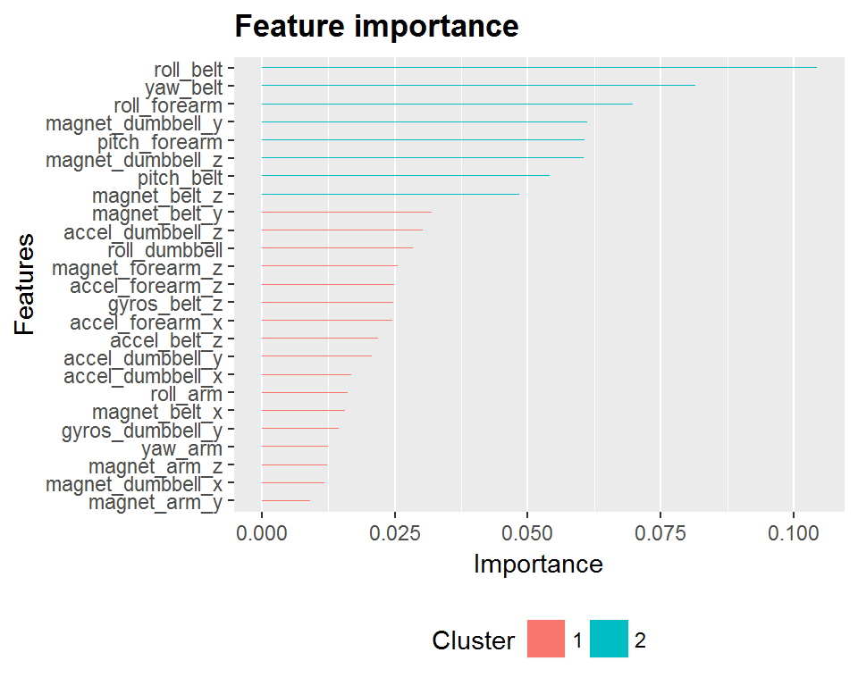

```r
importance <- xgb.importance(xgb$finalModel, feature_names = colnames(predictors))
xgb.ggplot.importance(importance[1:25,]) + theme(legend.position = 'bottom')
```

The most “important” predictor in this model is roll_belt. The measure of importance used for GBMs is gain, which is simply the observed improvement in accuracy whenever a specific predictor is added to each branch on which it appears.

### Predicting Test Data

Since we’re comfortable with this model’s performance on training data, I will now use it to predict the outcome of the 20 test cases.

```r
# Apply the same pre-processing
test_predictors <- test %>% select(-c(V1, user_name, raw_timestamp_part_1,
                                      raw_timestamp_part_2, cvtd_timestamp,
                                      new_window, num_window, skewness_roll_belt.1))
test_predictors <- as.data.frame(lapply(test_predictors, as.numeric))
test_predictors[is.na(test_predictors)] <- -1e6

# Store the predictions
test$predicted <- predict.train(xgb, newdata = test_predictors)

# Save predictions
write.csv(test[,c(1,161)], file = 'test_predictions.csv', row.names = F)
```